# main

# Question

Download the customer-personality.csv data from Moodle. This dataset contains information of customers that can make the company better understand the behaviour of their customers. Explore the dataset and report any interesting findings.

# Main Code

Import the required libraries

```r
library(ggplot2)
library(reshape)
library(dplyr)
library(GGally)
library(corrplot)
library(lubridate)
library(forcats)
library(readr)
library(reshape)
library(polycor)
library(EFA.dimensions)
library(fastICA)
library(tidyr)
library(stringr)
library(grid)
library(gridExtra)
library(ica)
library(scatterplot3d)
library(factoextra)
```

## I. Preprocess the data

We are going to preprocess the data as follows:

1. Remove the row with missing values
2. Remove the outliers from income and birth year
3. Convert ‘Education’, ‘Marital status’, and ‘Dt_Customer’ variables to categorical variables
- Create 3 categories for ‘Education’: “Basic” <- 1 “Graduation” <- 2 “2n Cycle” <- 3 “Master” <- 3 “PhD” <- 3
- Create 2 categories for ‘Marital status’ based on whether they are alone or not: “Absurd” <- 0 “Alone” <- 0 “YOLO” <- 0 “Single” <- 0 “Together” <- 1 “Married” <- 1 “Divorced” <- 0 “Widow” <- 0
- Create 3 categories for Dt_Customer by the year they joined “2012” <- 1 “2013” <- 2 “2014” <- 3
4. Add age variable
5. Filter the data which we need and turn them into numeric variables

```r
# import data
data.ori = read.csv("customer-personality.csv")

# summary of data
str(data.ori)
```

```
## 'data.frame':    2240 obs. of  20 variables:
##  $ ID                 : int  5524 2174 4141 6182 5324 7446 965 6177 4855 5899 ...
##  $ Year_Birth         : int  1957 1954 1965 1984 1981 1967 1971 1985 1974 1950 ...
##  $ Education          : chr  "Graduation" "Graduation" "Graduation" "Graduation" ...
##  $ Marital_Status     : chr  "Single" "Single" "Together" "Together" ...
##  $ Income             : int  58138 46344 71613 26646 58293 62513 55635 33454 30351 5648 ...
##  $ Kidhome            : int  0 1 0 1 1 0 0 1 1 1 ...
##  $ Teenhome           : int  0 1 0 0 0 1 1 0 0 1 ...
##  $ Dt_Customer        : chr  "04-09-2012" "08-03-2014" "21-08-2013" "10-02-2014" ...
##  $ Recency            : int  58 38 26 26 94 16 34 32 19 68 ...
##  $ MntWines           : int  635 11 426 11 173 520 235 76 14 28 ...
##  $ MntFruits          : int  88 1 49 4 43 42 65 10 0 0 ...
##  $ MntMeatProducts    : int  546 6 127 20 118 98 164 56 24 6 ...
##  $ MntFishProducts    : int  172 2 111 10 46 0 50 3 3 1 ...
##  $ MntSweetProducts   : int  88 1 21 3 27 42 49 1 3 1 ...
##  $ MntGoldProds       : int  88 6 42 5 15 14 27 23 2 13 ...
##  $ NumDealsPurchases  : int  3 2 1 2 5 2 4 2 1 1 ...
##  $ NumWebPurchases    : int  8 1 8 2 5 6 7 4 3 1 ...
##  $ NumCatalogPurchases: int  10 1 2 0 3 4 3 0 0 0 ...
##  $ NumStorePurchases  : int  4 2 10 4 6 10 7 4 2 0 ...
##  $ NumWebVisitsMonth  : int  7 5 4 6 5 6 6 8 9 20 ...
```

```r
# check for NA
sum(is.na(data.ori))
```

```
## [1] 24
```

```r
# check which columns contain NA
apply(is.na(data.ori), 2, which)
```

```
## $ID
## integer(0)
##
## $Year_Birth
## integer(0)
##
## $Education
## integer(0)
##
## $Marital_Status
## integer(0)
##
## $Income
##  [1]   11   28   44   49   59   72   91   92   93  129  134  313  320 1380 1383
## [16] 1384 1387 2060 2062 2079 2080 2082 2085 2229
##
## $Kidhome
## integer(0)
##
## $Teenhome
## integer(0)
##
## $Dt_Customer
## integer(0)
##
## $Recency
## integer(0)
##
## $MntWines
## integer(0)
##
## $MntFruits
## integer(0)
##
## $MntMeatProducts
## integer(0)
##
## $MntFishProducts
## integer(0)
##
## $MntSweetProducts
## integer(0)
##
## $MntGoldProds
## integer(0)
##
## $NumDealsPurchases
## integer(0)
##
## $NumWebPurchases
## integer(0)
##
## $NumCatalogPurchases
## integer(0)
##
## $NumStorePurchases
## integer(0)
##
## $NumWebVisitsMonth
## integer(0)
```

```r
# remove NA rows
data.clean = data.ori[which(!is.na(data.ori$Income)),]
str(data.clean)
```

```
## 'data.frame':    2216 obs. of  20 variables:
##  $ ID                 : int  5524 2174 4141 6182 5324 7446 965 6177 4855 5899 ...
##  $ Year_Birth         : int  1957 1954 1965 1984 1981 1967 1971 1985 1974 1950 ...
##  $ Education          : chr  "Graduation" "Graduation" "Graduation" "Graduation" ...
##  $ Marital_Status     : chr  "Single" "Single" "Together" "Together" ...
##  $ Income             : int  58138 46344 71613 26646 58293 62513 55635 33454 30351 5648 ...
##  $ Kidhome            : int  0 1 0 1 1 0 0 1 1 1 ...
##  $ Teenhome           : int  0 1 0 0 0 1 1 0 0 1 ...
##  $ Dt_Customer        : chr  "04-09-2012" "08-03-2014" "21-08-2013" "10-02-2014" ...
##  $ Recency            : int  58 38 26 26 94 16 34 32 19 68 ...
##  $ MntWines           : int  635 11 426 11 173 520 235 76 14 28 ...
##  $ MntFruits          : int  88 1 49 4 43 42 65 10 0 0 ...
##  $ MntMeatProducts    : int  546 6 127 20 118 98 164 56 24 6 ...
##  $ MntFishProducts    : int  172 2 111 10 46 0 50 3 3 1 ...
##  $ MntSweetProducts   : int  88 1 21 3 27 42 49 1 3 1 ...
##  $ MntGoldProds       : int  88 6 42 5 15 14 27 23 2 13 ...
##  $ NumDealsPurchases  : int  3 2 1 2 5 2 4 2 1 1 ...
##  $ NumWebPurchases    : int  8 1 8 2 5 6 7 4 3 1 ...
##  $ NumCatalogPurchases: int  10 1 2 0 3 4 3 0 0 0 ...
##  $ NumStorePurchases  : int  4 2 10 4 6 10 7 4 2 0 ...
##  $ NumWebVisitsMonth  : int  7 5 4 6 5 6 6 8 9 20 ...
```

```r
sum(is.na(data.clean))
```

```
## [1] 0
```

```r
# remove outliers from income and birth year
## income
data.clean <- data.clean[!(data.clean$Income >=200000),]

## birth year
data.clean <- data.clean[!(data.clean$Year_Birth <=1901),]
```

```r
# converting 'Education', 'Marital status', and 'Dt_Customer' variables to categorical variables
## Education - Creating 3 categories
data.clean$Education[data.clean$Education == "Basic"] <- "1"
data.clean$Education[data.clean$Education == "Graduation"] <- "2"
data.clean$Education[data.clean$Education == "2n Cycle"] <- "3"
data.clean$Education[data.clean$Education == "Master"] <- "3"
data.clean$Education[data.clean$Education == "PhD"] <- "3"
data.clean$Education <- as.numeric(data.clean$Education)

## Marital Status - Creating 2 categories of Single and together
data.clean$Marital_Status[data.clean$Marital_Status == "Absurd"] <- 0
data.clean$Marital_Status[data.clean$Marital_Status == "Alone"] <- 0
data.clean$Marital_Status[data.clean$Marital_Status == "YOLO"] <- 0
data.clean$Marital_Status[data.clean$Marital_Status == "Single"] <- 0
data.clean$Marital_Status[data.clean$Marital_Status == "Together"] <- 1
data.clean$Marital_Status[data.clean$Marital_Status == "Married"] <- 1
data.clean$Marital_Status[data.clean$Marital_Status == "Divorced"] <- 0
data.clean$Marital_Status[data.clean$Marital_Status == "Widow"] <- 0
data.clean$Marital_Status <- as.numeric(data.clean$Marital_Status)

## Dt_customer
data.clean$Dt_Customer <- dmy(data.clean$Dt_Customer)
data.clean$Dt_Customer <- year(data.clean$Dt_Customer)
data.clean$Dt_Customer <- as.factor(data.clean$Dt_Customer)

data.clean$Dt_Customer <- fct_collapse(data.clean$Dt_Customer,
                                      "3" = "2014",
                                      "1" = "2012",
                                      "2" = "2013")

data.clean$Dt_Customer <- as.numeric(levels(data.clean$Dt_Customer))[data.clean$Dt_Customer]
```

```r
# Adding Age variable
data.clean$Age <- (2015 - data.clean$Year_Birth)
```

```r
# filter numerical columns
numerical.data = data.clean[, c(3:21)]#:ncol(data.ori))]
str(numerical.data)
```

```
## 'data.frame':    2212 obs. of  19 variables:
##  $ Education          : num  2 2 2 2 3 3 2 3 3 3 ...
##  $ Marital_Status     : num  0 0 1 1 1 1 0 1 1 1 ...
##  $ Income             : int  58138 46344 71613 26646 58293 62513 55635 33454 30351 5648 ...
##  $ Kidhome            : int  0 1 0 1 1 0 0 1 1 1 ...
##  $ Teenhome           : int  0 1 0 0 0 1 1 0 0 1 ...
##  $ Dt_Customer        : num  1 3 2 3 3 2 1 2 2 3 ...
##  $ Recency            : int  58 38 26 26 94 16 34 32 19 68 ...
##  $ MntWines           : int  635 11 426 11 173 520 235 76 14 28 ...
##  $ MntFruits          : int  88 1 49 4 43 42 65 10 0 0 ...
##  $ MntMeatProducts    : int  546 6 127 20 118 98 164 56 24 6 ...
##  $ MntFishProducts    : int  172 2 111 10 46 0 50 3 3 1 ...
##  $ MntSweetProducts   : int  88 1 21 3 27 42 49 1 3 1 ...
##  $ MntGoldProds       : int  88 6 42 5 15 14 27 23 2 13 ...
##  $ NumDealsPurchases  : int  3 2 1 2 5 2 4 2 1 1 ...
##  $ NumWebPurchases    : int  8 1 8 2 5 6 7 4 3 1 ...
##  $ NumCatalogPurchases: int  10 1 2 0 3 4 3 0 0 0 ...
##  $ NumStorePurchases  : int  4 2 10 4 6 10 7 4 2 0 ...
##  $ NumWebVisitsMonth  : int  7 5 4 6 5 6 6 8 9 20 ...
##  $ Age                : num  58 61 50 31 34 48 44 30 41 65 ...
```

## II. Exploratory Data Analysis

We are going to explore the data as follows:

1. Show the orrelation between the variables
2. Plot the histogram

```
##                    Var1                Var2       Freq
## 295     MntMeatProducts NumCatalogPurchases  0.7337875
## 288              Income NumCatalogPurchases  0.6965886
## 174              Income     MntMeatProducts  0.6922788
## 136              Income            MntWines  0.6882093
## 326              Income   NumWebVisitsMonth -0.6502567
## 312            MntWines   NumStorePurchases  0.6402194
## 293            MntWines NumCatalogPurchases  0.6342367
## 307              Income   NumStorePurchases  0.6314244
## 199           MntFruits     MntFishProducts  0.5930383
## 220     MntFishProducts    MntSweetProducts  0.5834842
## 200     MntMeatProducts     MntFishProducts  0.5729861
## 218           MntFruits    MntSweetProducts  0.5714738
## 179            MntWines     MntMeatProducts  0.5680808
## 274            MntWines     NumWebPurchases  0.5536631
## 180           MntFruits     MntMeatProducts  0.5467400
## 333     MntMeatProducts   NumWebVisitsMonth -0.5391937
## 219     MntMeatProducts    MntSweetProducts  0.5346240
## 296     MntFishProducts NumCatalogPurchases  0.5322408
## 212              Income    MntSweetProducts  0.5235985
## 339 NumCatalogPurchases   NumWebVisitsMonth -0.5220229
## 193              Income     MntFishProducts  0.5200398
## 320 NumCatalogPurchases   NumStorePurchases  0.5178870
## 319     NumWebPurchases   NumStorePurchases  0.5157556
## 60               Income             Kidhome -0.5145228
## 155              Income           MntFruits  0.5073538
## 289             Kidhome NumCatalogPurchases -0.5045981
## 308             Kidhome   NumStorePurchases -0.5018631
```

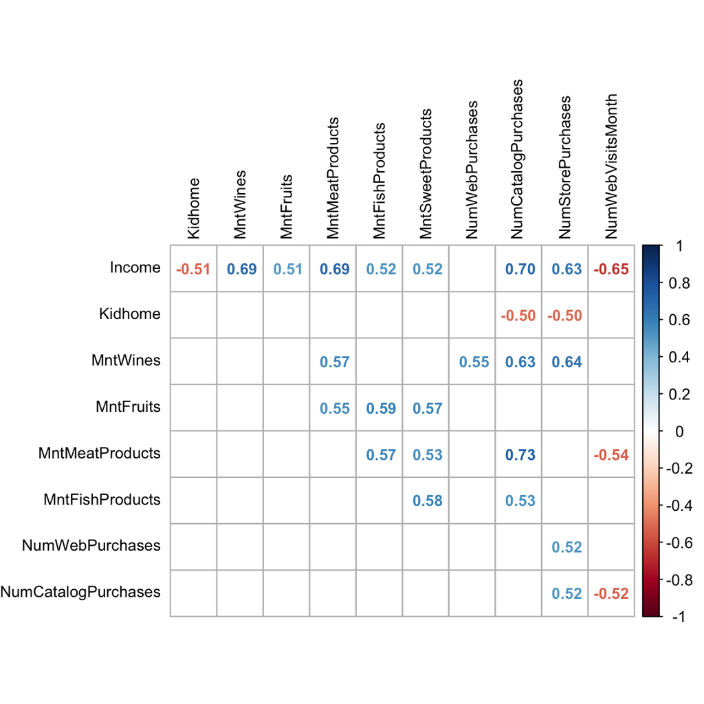

```r
par(mfrow=c(1,1))
corr_simple <- function(data=numerical.data,sig=0.5){
  #convert data to numeric in order to run correlations
  #convert to factor first to keep the integrity of the data - each value will become a number rather than turn into NA
  df_cor <- data %>% mutate_if(is.character, as.factor)
  df_cor <- df_cor %>% mutate_if(is.factor, as.numeric)
  #run a correlation and drop the insignificant ones
  corr <- cor(df_cor)
  #prepare to drop duplicates and correlations of 1
  corr[lower.tri(corr,diag=TRUE)] <- NA
  #drop perfect correlations
  corr[corr == 1] <- NA
  #turn into a 3-column table
  corr <- as.data.frame(as.table(corr))
  #remove the NA values from above
  corr <- na.omit(corr)
  #select significant values
  corr <- subset(corr, abs(Freq) > sig)
  #sort by highest correlation
  corr <- corr[order(-abs(corr$Freq)),]
  #print table
  print(corr)
  #turn corr back into matrix in order to plot with corrplot
  mtx_corr <- reshape2::acast(corr, Var1~Var2, value.var="Freq")

  #plot correlations visually
  corrplot(mtx_corr, is.corr=T, tl.col="black", method = 'number', na.label=" ", number.cex=0.8 ,tl.cex=0.8)
}
corr_simple()
```

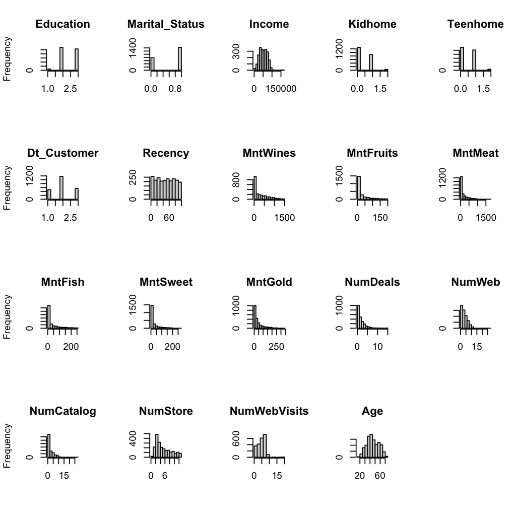

```r
par(mfrow=c(4,5))
hist(data.clean$Education, main="Education", xlab=" ")
hist(data.clean$Marital_Status, main="Marital_Status", xlab=" ", ylab = " ")
hist(data.clean$Income, main="Income", xlab=" ", ylab = " ")
hist(data.clean$Kidhome, main="Kidhome", xlab=" ", ylab = " ")
hist(data.clean$Teenhome, main="Teenhome", xlab=" ", ylab = " ")
hist(data.clean$Dt_Customer, main="Dt_Customer", xlab=" ")
hist(data.clean$Recency, main="Recency", xlab=" ", ylab = " ")
hist(data.clean$MntWines, main="MntWines", xlab=" ", ylab = " ")
hist(data.clean$MntFruits, main="MntFruits", xlab=" ", ylab = " ")
hist(data.clean$MntMeatProducts, main="MntMeat", xlab=" ", ylab = " ")
hist(data.clean$MntFishProducts, main="MntFish", xlab=" ")
hist(data.clean$MntSweetProducts, main="MntSweet", xlab=" ", ylab = " ")
hist(data.clean$MntGoldProds, main="MntGold", xlab=" ", ylab = " ")
hist(data.clean$NumDealsPurchases, main="NumDeals", xlab=" ", ylab = " ")
hist(data.clean$NumWebPurchases, main="NumWeb", xlab=" ", ylab = " ")
hist(data.clean$NumCatalogPurchases, main="NumCatalog", xlab=" ")
hist(data.clean$NumStorePurchases, main="NumStore", xlab=" ", ylab = " ")
hist(data.clean$NumWebVisitsMonth, main="NumWebVisits", xlab=" ", ylab = " ")
hist(data.clean$Age, main="Age", xlab=" ", ylab = " ")


par(mfrow=c(1,1))
```

```r
features.order = c("Education", "Marital_Status", "Kidhome", "Teenhome", "Age",
                   "Dt_Customer", "Income", "Recency", "MntWines", "MntFruits",
                   "MntMeatProducts", "MntFishProducts", "MntSweetProducts",
                   "MntGoldProds", "NumDealsPurchases", "NumWebPurchases",
                   "NumCatalogPurchases", "NumStorePurchases", "NumWebVisitsMonth")
```

## III. Dimensionality Reduction

In this part, we are going to compare the dimensionality reduction techniques (eg. FA, PCA and ICA) and see which one is the best.

### 1. FA

Here is the procedure for FA: 1. Use eigenvalues to find the number of principal components. 2. Use factanal function to calculate the final result. 3. Create a new data frame with the selected principal components for heatmap.

We are not suppose to use Pearson correlation as not all of the variables are numerical. Instead, we should use polychroic correlation. However, because the polychroic correlation is computational expensive, when we apply this algorithm into the data, we will still get the Pearson correlation.

```r
# get the polychroic correlation
fa.cor = POLYCHORIC_R(numerical.data)
```

```
##
## Using the Fox polycor package because the maximum number of item categories is > 8
```

```
##
## Types of correlations computed by hetcor:
```

[output not shown]

[output cut: 45 more lines]

[output not shown]

```
##
## Polychoric correlations:
```

```
##                        Education Marital_Status       Income     Kidhome
## Education            1.000000000    0.014819894  0.122894646 -0.02913426
## Marital_Status       0.014819894    1.000000000 -0.004803202  0.02689790
## Income               0.122894646   -0.004803202  1.000000000 -0.51452275
## Kidhome             -0.029134255    0.026897899 -0.514522754  1.00000000
## Teenhome             0.091144559    0.032319553  0.034564671 -0.03906554
## Dt_Customer          0.041533972    0.010990374  0.026594219  0.05355987
## Recency             -0.026538728   -0.000416739  0.007965318  0.01062258
## MntWines             0.134233141   -0.008473288  0.688209275 -0.49720269
## MntFruits           -0.071639937   -0.027676756  0.507353793 -0.37325839
## MntMeatProducts      0.006450273   -0.024603415  0.692278785 -0.43903111
## MntFishProducts     -0.064375485   -0.018922705  0.520039771 -0.38864307
## MntSweetProducts    -0.063590258   -0.016805285  0.523598534 -0.37784254
## MntGoldProds        -0.085117643   -0.027224411  0.388299360 -0.35492197
## NumDealsPurchases    0.031514928    0.025287367 -0.108206898  0.21659438
## NumWebPurchases      0.062377186    0.002452383  0.459265143 -0.37232725
## NumCatalogPurchases  0.045748941   -0.010966462  0.696588565 -0.50459809
## NumStorePurchases    0.070906342    0.003577720  0.631424404 -0.50186308
## NumWebVisitsMonth   -0.043135013    0.003117794 -0.650256696  0.44725846
## Age                  0.122274304    0.003691569  0.199976646 -0.23749696
##                         Teenhome Dt_Customer       Recency     MntWines
## Education            0.091144559  0.04153397 -0.0265387282  0.134233141
## Marital_Status       0.032319553  0.01099037 -0.0004167390 -0.008473288
## Income               0.034564671  0.02659422  0.0079653182  0.688209275
## Kidhome             -0.039065540  0.05355987  0.0106225805 -0.497202694
## Teenhome             1.000000000 -0.01013367  0.0143918617  0.003944817
## Dt_Customer         -0.010133672  1.00000000 -0.0265227409 -0.154646727
## Recency              0.014391862 -0.02652274  1.0000000000  0.015980563
## MntWines             0.003944817 -0.15464673  0.0159805629  1.000000000
## MntFruits           -0.175904895 -0.05464003 -0.0052565190  0.385844205
## MntMeatProducts     -0.261134042 -0.07820885  0.0229135908  0.568080769
## MntFishProducts     -0.205234706 -0.06703349  0.0007877526  0.396915113
## MntSweetProducts    -0.163107426 -0.07344425  0.0252439031  0.389582942
## MntGoldProds        -0.018579437 -0.14365865  0.0181483988  0.391461082
## NumDealsPurchases    0.386805180 -0.18505839  0.0025905674  0.009117406
## NumWebPurchases      0.162238646 -0.16915315 -0.0056803204  0.553663070
## NumCatalogPurchases -0.112477230 -0.08551607  0.0241967754  0.634236713
## NumStorePurchases    0.049211531 -0.09695195 -0.0004599153  0.640219442
## NumWebVisitsMonth    0.130984620 -0.25333675 -0.0189652560 -0.321616220
## Age                  0.361931763  0.02404126  0.0156943409  0.164614642
```

[output cut: 65 more lines]

```
## Teenhome                  0.130984620  0.361931763
## Dt_Customer              -0.253336754  0.024041257
## Recency                  -0.018965256  0.015694341
## MntWines                 -0.321616220  0.164614642
## MntFruits                -0.417741086  0.013446942
## MntMeatProducts          -0.539193740  0.033621938
## MntFishProducts          -0.446150668  0.041153853
## MntSweetProducts         -0.422288782  0.021516101
## MntGoldProds             -0.245972715  0.059779225
## NumDealsPurchases         0.345622719  0.066156189
## NumWebPurchases          -0.051588559  0.162265402
## NumCatalogPurchases      -0.522022942  0.125856145
## NumStorePurchases        -0.433812923  0.138997589
## NumWebVisitsMonth         1.000000000 -0.120282351
## Age                      -0.120282351  1.000000000
```